# R_TUTORIAL_DESCRIPTIVES

# Welcome to the tutorial on statistics in R!

Goals: 1. Learn how to run simple statistical tests in R 2. Learn how to visualize the results of the models

# First things first:

# 1. Correlations

Correlations are as simple as it gets in R. Use the cor() function with your two variables to get the correlation coefficient. or use the cor.test() function to get the t, df, and p-value associated with your correlaton coefficient.

```r
cor(mtcars$mpg, mtcars$wt)
```

```
## [1] -0.8676594
```

```r
cor.test(mtcars$mpg, mtcars$wt)
```

```
##
##  Pearson's product-moment correlation
##
## data:  mtcars$mpg and mtcars$wt
## t = -9.559, df = 30, p-value = 1.294e-10
## alternative hypothesis: true correlation is not equal to 0
## 95 percent confidence interval:
##  -0.9338264 -0.7440872
## sample estimates:
##        cor
## -0.8676594
```

# 2. T-tests

First, let’s check that our variance is not heterogenous between the two groups. We can do this by calling the leveneTest() function, which performs the Levene’s test of Equality of Variances.

```r
leveneTest(mtcars$mpg, mtcars$vs) # we do not reject the null
```

```
## Levene's Test for Homogeneity of Variance (center = median)
##       Df F value Pr(>F)
## group  1  1.5922 0.2167
##       30
```

```r
t.test(mtcars$mpg, mtcars$vs)
```

```
##
##  Welch Two Sample t-test
##
## data:  mtcars$mpg and mtcars$vs
## t = 18.382, df = 31.434, p-value < 2.2e-16
## alternative hypothesis: true difference in means is not equal to 0
## 95 percent confidence interval:
##  17.47381 21.83244
## sample estimates:
## mean of x mean of y
##  20.09062   0.43750
```

In the case you want to use a ‘Students’ t-test (SPSS default, asumes homogenous variances) you can specify that with the argument var.equal=TRUE.There are many other options here, including a paired samples t-test (more on that in the data challenge!)

```r
t.test(mtcars$mpg, mtcars$vs, var.equal=TRUE)
```

```
##
##  Two Sample t-test
##
## data:  mtcars$mpg and mtcars$vs
## t = 18.382, df = 62, p-value < 2.2e-16
## alternative hypothesis: true difference in means is not equal to 0
## 95 percent confidence interval:
##  17.51594 21.79031
## sample estimates:
## mean of x mean of y
##  20.09062   0.43750
```

# 3. Anova

A word of cauton using statistics in R: there are many ways to run each statistical test. For an ANOVA, there are several didfferent packages that have different ways of running the ANOVA ‘under the hood’, or just use different conventions in reporting the results. To start with, we will show you how to run simple one-way and two-way anovas.

```r
# first we have to convert these binary variables into factors, instead of "numeric"
class(mtcars$vs)
```

```
## [1] "numeric"
```

```r
class(mtcars$am)
```

```
## [1] "numeric"
```

```r
mtcars$vs.factor <- as.factor(mtcars$vs)
mtcars$am.factor <- as.factor(mtcars$am)
class(mtcars$am.factor)
```

```
## [1] "factor"
```

```r
class(mtcars$vs.factor)
```

```
## [1] "factor"
```

one -way anova

```r
mtcars$am.factor <- as.factor(mtcars$am)
aov_1 <- aov(mpg ~ am.factor, data = mtcars )
summary(aov_1) # anova output
```

```
##             Df Sum Sq Mean Sq F value   Pr(>F)
## am.factor    1  405.2   405.2   16.86 0.000285 ***
## Residuals   30  720.9    24.0
## ---
## Signif. codes:  0 '***' 0.001 '**' 0.01 '*' 0.05 '.' 0.1 ' ' 1
```

```r
coefficients(aov_1) # coefficients (betas)
```

```
## (Intercept)  am.factor1
##   17.147368    7.244939
```

two -way anova

```r
aov_2 <- aov(mpg ~ am.factor*vs.factor, data = mtcars )
summary(aov_2)
```

```
##                     Df Sum Sq Mean Sq F value   Pr(>F)
## am.factor            1  405.2   405.2  33.615 3.16e-06 ***
## vs.factor            1  367.4   367.4  30.484 6.69e-06 ***
## am.factor:vs.factor  1   16.0    16.0   1.328    0.259
## Residuals           28  337.5    12.1
## ---
## Signif. codes:  0 '***' 0.001 '**' 0.01 '*' 0.05 '.' 0.1 ' ' 1
```

```r
coefficients(aov_2)
```

```
##           (Intercept)            am.factor1            vs.factor1
##             15.050000              4.700000              5.692857
## am.factor1:vs.factor1
##              2.928571
```

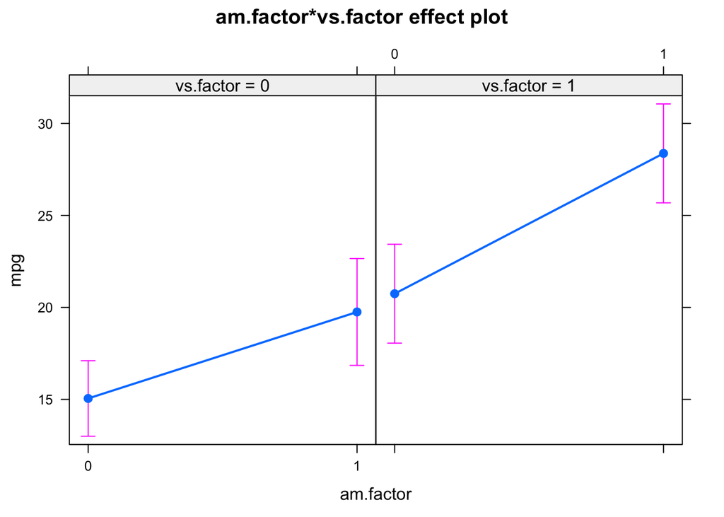

```r
plot(allEffects(aov_2))
```

Post-hoc comparisons for 2x2 anova. Again, note there are many options for posthoc tests depending on the assumptions of your data. Here we will learn Tukey’s post-hoc, which is commonly used in the ANOVA framework in psychology. We will get the post-hoc contrasts for each level of the interaction using the function TukeyHSD(). The argument for the function is the model, whch we just created above.

```r
post_hoc <- TukeyHSD(aov_2)
```

We can now look at the 6 contrasts of the 2x2 interaction by indexing the results of the TukeyHSD() function.

```r
post_hoc$`am.factor:vs.factor`
```

```
##               diff         lwr       upr        p adj
## 1:0-0:0  4.7000000 -0.03941699  9.439417 5.255362e-02
## 0:1-0:0  5.6928571  1.18477237 10.200942 9.217337e-03
## 1:1-0:0 13.3214286  8.81334379 17.829513 5.108062e-08
## 0:1-1:0  0.9928571 -4.28067926  6.266394 9.550456e-01
## 1:1-1:0  8.6214286  3.34789217 13.894965 6.578492e-04
## 1:1-0:1  7.6285714  2.56192154 12.695221 1.678892e-03
```

# 4. linear regression

Linear regression follow this formula: lm( y ~ x, data) where lm() is the function of the linear model. We will use the summary() function, with our model as input, to easly view a table of the results of the model.

```r
model1 <- lm(mpg ~ wt, data = mtcars )

summary(model1)
```

```
##
## Call:
## lm(formula = mpg ~ wt, data = mtcars)
##
## Residuals:
##     Min      1Q  Median      3Q     Max
## -4.5432 -2.3647 -0.1252  1.4096  6.8727
##
## Coefficients:
##             Estimate Std. Error t value Pr(>|t|)
## (Intercept)  37.2851     1.8776  19.858  < 2e-16 ***
## wt           -5.3445     0.5591  -9.559 1.29e-10 ***
## ---
## Signif. codes:  0 '***' 0.001 '**' 0.01 '*' 0.05 '.' 0.1 ' ' 1
##
## Residual standard error: 3.046 on 30 degrees of freedom
## Multiple R-squared:  0.7528, Adjusted R-squared:  0.7446
## F-statistic: 91.38 on 1 and 30 DF,  p-value: 1.294e-10
```

The effect package provides a simple way to visualize the results of your model. we can quicky plot the linear regression slope with a 95% confidence interval. Like many R functions, there are many addtional arguments that will allow you to customize the plot and make it prettier.

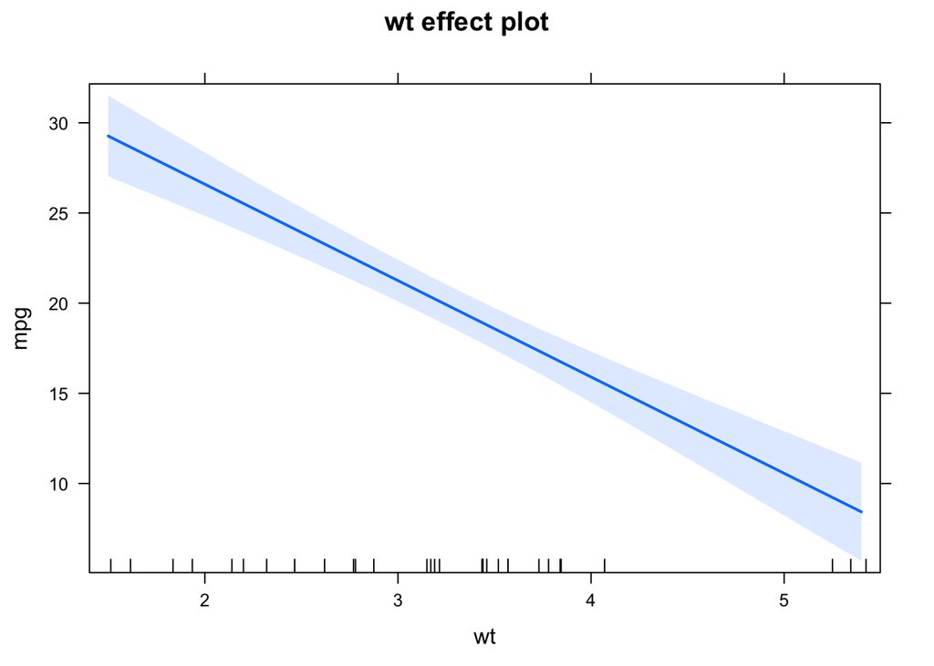

```r
plot(effect("wt", model1))
```

[figure not shown]

```r
plot(effect("wt", model1), main = "", xlab = "miles per gallon", ylab = "weight of the car", rug = F)
```